# Analisis Abejas polinizadoras

Cesar Peñaranda, Keyla, Kevin

2023-11-18

# Anotaciones

- Vamos a analizar el efecto del tiempo en las especies, donde la zona es un efecto aleatorio dado que proviene de una poblacion mas amplia
- El mes no es un bloque, es una medida repetida
- Librerias
- Codigos de mes

```r
noviembre2018 = 1
marzo2019     = 2
abril2019     = 3
octubre2019   = 4
noviembre2019 = 5
marzo2020     = 6
```

- Codigos de especie

```r
Apis_mellifera       = "apis"
Euglossa_viridissima = "euglo"
Polybia_occidentalis = "poly"
Toxomerus_2          = "toxo"
Trigona_corvina      = "trigo"
```

- Carga de la base

```r
load("bases/base_abejas.Rdata")
levels(base_abejas$especie)=c("apis","euglo","poly","toxo","trigo")
str(base_abejas)
```

```
## tibble [120 × 4] (S3: tbl_df/tbl/data.frame)
##  $ conteo : num [1:120] 10 10 10 10 0 0 0 0 0 0 ...
##  $ zona   : Factor w/ 4 levels "garzas","josema",..: 1 3 2 4 1 3 2 4 1 3 ...
##  $ especie: Factor w/ 5 levels "apis","euglo",..: 1 1 1 1 2 2 2 2 3 3 ...
##  $ mes    : num [1:120] 1 1 1 1 1 1 1 1 1 1 ...
```

Columna del total de conteo para cada zona en cada mes

```r
total <- base_abejas %>%
  group_by(zona, mes) %>%
  mutate(x = sum(conteo))
print(total)
```

```
## # A tibble: 120 × 5
## # Groups:   zona, mes [24]
##    conteo zona    especie   mes     x
##     <dbl> <fct>   <fct>   <dbl> <dbl>
##  1     10 garzas  apis        1    11
##  2     10 leona   apis        1    10
##  3     10 josema  apis        1    10
##  4     10 soncoyo apis        1    10
##  5      0 garzas  euglo       1    11
##  6      0 leona   euglo       1    10
##  7      0 josema  euglo       1    10
##  8      0 soncoyo euglo       1    10
##  9      0 garzas  poly        1    11
## 10      0 leona   poly        1    10
## # ℹ 110 more rows
```

```r
base_abejas$total=total$x
base_abejas %>% arrange(zona)
```

```
## # A tibble: 120 × 5
##    conteo zona   especie   mes total
##     <dbl> <fct>  <fct>   <dbl> <dbl>
##  1     10 garzas apis        1    11
##  2      0 garzas euglo       1    11
##  3      0 garzas poly        1    11
##  4      0 garzas toxo        1    11
##  5      1 garzas trigo       1    11
##  6     10 garzas apis        2    15
##  7      0 garzas euglo       2    15
##  8      0 garzas poly        2    15
##  9      0 garzas toxo        2    15
## 10      5 garzas trigo       2    15
## # ℹ 110 more rows
```

- Graficos proporcion de la especie segun finca y mes

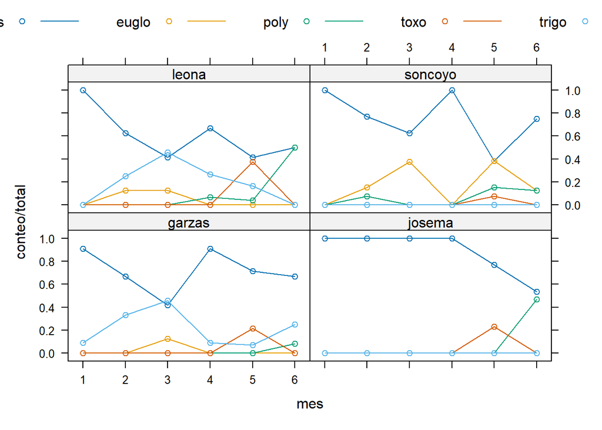

```r
xyplot(conteo/total~mes|zona,group=especie,type=c("a","p"),data=base_abejas,auto.key=list(columns=5))
```

- Grafico pendiente general

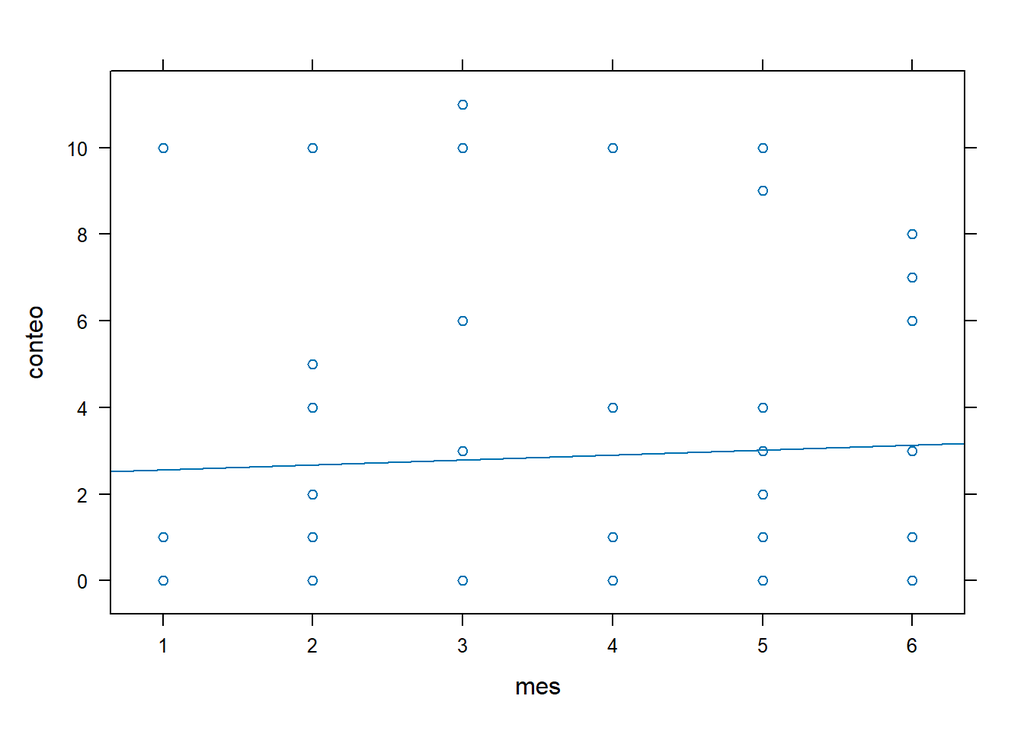

```r
xyplot(conteo~mes,type=c("r","p"),data=base_abejas,auto.key=list(columns=5))
```

**Se oberseva una tendencia al aumento pero minima**

- Grafico pendientes por zona

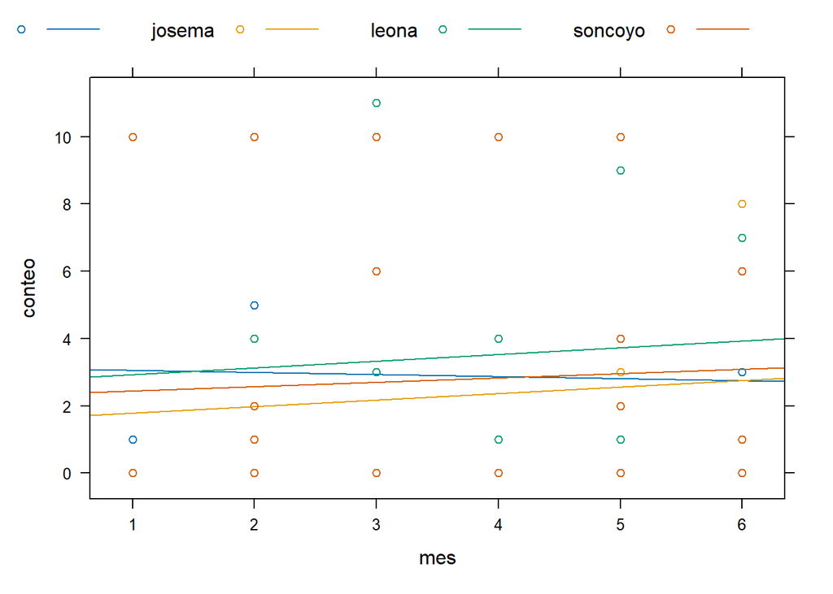

```r
xyplot(conteo~mes,group=zona,type=c("r","p"),data=base_abejas,auto.key=list(columns=5))
```

**Hay una tendencia al aumento minima, en finca garzas mas bien hay una tendencia negativa** - Grafico pendiente por especie segun zona

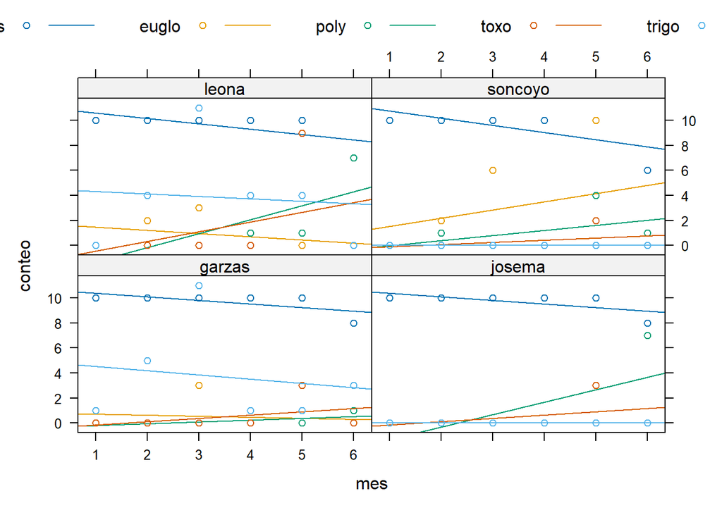

```r
xyplot(conteo~mes|zona,group=especie,type=c("r","p"),data=base_abejas,auto.key=list(columns=5))
```

# Modelos

- Modelo aleatorio poisson

```r
mod.p1=glmer(conteo~especie*mes+(1|zona)+(mes|zona),family = poisson,data = base_abejas)
```

```
## boundary (singular) fit: see help('isSingular')
```

```r
summary(mod.p1)
```

```
## Generalized linear mixed model fit by maximum likelihood (Laplace
##   Approximation) [glmerMod]
##  Family: poisson  ( log )
## Formula: conteo ~ especie * mes + (1 | zona) + (mes | zona)
##    Data: base_abejas
##
##      AIC      BIC   logLik deviance df.resid
##    477.4    516.4   -224.7    449.4      106
##
## Scaled residuals:
##     Min      1Q  Median      3Q     Max
## -1.5716 -1.0653 -0.3840  0.1881  7.9319
##
## Random effects:
##  Groups Name        Variance  Std.Dev.  Corr
##  zona   (Intercept) 2.011e-07 0.0004484
##  zona.1 (Intercept) 1.477e-02 0.1215195
##         mes         3.834e-05 0.0061923 -1.00
## Number of obs: 120, groups:  zona, 4
##
## Fixed effects:
##                  Estimate Std. Error z value Pr(>|z|)
## (Intercept)       2.39035    0.15949  14.988  < 2e-16 ***
## especieeuglo     -2.53227    0.48377  -5.234 1.65e-07 ***
## especiepoly      -7.75131    1.42087  -5.455 4.89e-08 ***
## especietoxo      -5.46748    1.00566  -5.437 5.43e-08 ***
## especietrigo     -1.52247    0.35607  -4.276 1.91e-05 ***
## mes              -0.04062    0.03901  -1.041  0.29773
## especieeuglo:mes  0.11133    0.11957   0.931  0.35184
## especiepoly:mes   1.15930    0.25610   4.527 5.99e-06 ***
## especietoxo:mes   0.67110    0.19682   3.410  0.00065 ***
## especietrigo:mes -0.03137    0.09583  -0.327  0.74340
## ---
## Signif. codes:  0 '***' 0.001 '**' 0.01 '*' 0.05 '.' 0.1 ' ' 1
##
## Correlation of Fixed Effects:
##             (Intr) espcgl espcpl espctx espctr mes    espcg: espcp: espctx:
## especieeugl -0.279
## especiepoly -0.095  0.031
## especietoxo -0.134  0.044  0.015
## especietrig -0.378  0.125  0.042  0.060
## mes         -0.853  0.269  0.092  0.129  0.365
## especigl:ms  0.266 -0.907 -0.030 -0.042 -0.119 -0.322
## especply:ms  0.124 -0.041 -0.986 -0.020 -0.056 -0.150  0.049
## especitx:ms  0.162 -0.053 -0.018 -0.966 -0.072 -0.195  0.064  0.030
## espectrg:ms  0.332 -0.109 -0.037 -0.053 -0.889 -0.401  0.131  0.061  0.080
## optimizer (Nelder_Mead) convergence code: 0 (OK)
## boundary (singular) fit: see help('isSingular')
```

- Modelo aleatorio binomial negativa

```r
mod.b1=glmer.nb(conteo~especie*mes+(1|zona)+(mes|zona),data = base_abejas)
```

```
## boundary (singular) fit: see help('isSingular')
```

```r
summary(mod.b1)
```

```
## Generalized linear mixed model fit by maximum likelihood (Laplace
##   Approximation) [glmerMod]
##  Family: Negative Binomial(0.9286)  ( log )
## Formula: conteo ~ especie * mes + (1 | zona) + (mes | zona)
##    Data: base_abejas
##
##      AIC      BIC   logLik deviance df.resid
##    435.4    477.2   -202.7    405.4      105
##
## Scaled residuals:
##     Min      1Q  Median      3Q     Max
## -0.8737 -0.6845 -0.2431  0.0371  4.9099
##
## Random effects:
##  Groups Name        Variance  Std.Dev.  Corr
##  zona   (Intercept) 5.891e-10 2.427e-05
##  zona.1 (Intercept) 1.085e-01 3.294e-01
##         mes         6.228e-04 2.496e-02 -1.00
## Number of obs: 120, groups:  zona, 4
##
## Fixed effects:
##                  Estimate Std. Error z value Pr(>|z|)
## (Intercept)       2.42128    0.54513   4.442 8.93e-06 ***
## especieeuglo     -2.73354    0.93934  -2.910 0.003613 **
## especiepoly      -7.56252    1.79235  -4.219 2.45e-05 ***
## especietoxo      -7.67187    2.17605  -3.526 0.000423 ***
## especietrigo     -1.51166    0.88825  -1.702 0.088784 .
## mes              -0.04483    0.13460  -0.333 0.739083
## especieeuglo:mes  0.15038    0.24073   0.625 0.532178
## especiepoly:mes   1.11449    0.35696   3.122 0.001795 **
## especietoxo:mes   1.13970    0.45872   2.485 0.012973 *
## especietrigo:mes -0.06006    0.23237  -0.258 0.796062
## ---
## Signif. codes:  0 '***' 0.001 '**' 0.01 '*' 0.05 '.' 0.1 ' ' 1
##
## Correlation of Fixed Effects:
##             (Intr) espcgl espcpl espctx espctr mes    espcg: espcp: espctx:
## especieeugl -0.540
## especiepoly -0.283  0.176
## especietoxo -0.231  0.142  0.075
## especietrig -0.573  0.359  0.187  0.152
## mes         -0.885  0.505  0.263  0.217  0.536
## especigl:ms  0.487 -0.917 -0.151 -0.126 -0.321 -0.561
## especply:ms  0.329 -0.202 -0.964 -0.086 -0.214 -0.376  0.214
## especitx:ms  0.254 -0.153 -0.079 -0.976 -0.163 -0.293  0.168  0.113
## espectrg:ms  0.504 -0.306 -0.156 -0.131 -0.913 -0.581  0.337  0.222  0.175
## optimizer (Nelder_Mead) convergence code: 0 (OK)
## boundary (singular) fit: see help('isSingular')
```

- Seleccion del modelo a trabajar H0 los dos modelos explican lo mismo

```r
anova(mod.p1,mod.b1,test="LRT")
```

```
## Data: base_abejas
## Models:
## mod.p1: conteo ~ especie * mes + (1 | zona) + (mes | zona)
## mod.b1: conteo ~ especie * mes + (1 | zona) + (mes | zona)
##        npar    AIC    BIC  logLik deviance  Chisq Df Pr(>Chisq)
## mod.p1   14 477.39 516.41 -224.69   449.39
## mod.b1   15 435.43 477.24 -202.72   405.43 43.958  1  3.355e-11 ***
## ---
## Signif. codes:  0 '***' 0.001 '**' 0.01 '*' 0.05 '.' 0.1 ' ' 1
```

**Se rechaza H0 con un p<0.05, ademas el modelo con el menor AIC (435.43) es el de la binomial negativa por lo que es el que se ajusta mejor**

- Pruebas formales

H0 independencia entre pendientes e interceptos aleatorios

```r
mod.b1=glmer.nb(conteo~especie*mes+(1|zona)+(0+mes|zona),data = base_abejas)
mod.b2=glmer.nb(conteo~especie*mes+(mes|zona),data = base_abejas)
```

```
## boundary (singular) fit: see help('isSingular')
```

```r
anova(mod.b1,mod.b2)
```

```
## Data: base_abejas
## Models:
## mod.b1: conteo ~ especie * mes + (1 | zona) + (0 + mes | zona)
## mod.b2: conteo ~ especie * mes + (mes | zona)
##        npar    AIC    BIC  logLik deviance  Chisq Df Pr(>Chisq)
## mod.b1   13 431.52 467.76 -202.76   405.52
## mod.b2   14 433.43 472.46 -202.72   405.43 0.0856  1     0.7698
```

**No hay suficiente evidencia estadistica para rechazar H0**

H0 pendientes aleatorias iguales

```r
#mod.b1=glmer.nb(conteo~especie*mes+(1|zona)+(0+mes|zona),data = base_abejas)
mod.b3=glmer.nb(conteo~especie*mes+(1|zona),data = base_abejas)
anova(mod.b1,mod.b3)
```

```
## Data: base_abejas
## Models:
## mod.b3: conteo ~ especie * mes + (1 | zona)
## mod.b1: conteo ~ especie * mes + (1 | zona) + (0 + mes | zona)
##        npar    AIC    BIC  logLik deviance Chisq Df Pr(>Chisq)
## mod.b3   12 429.52 462.97 -202.76   405.52
## mod.b1   13 431.52 467.76 -202.76   405.52     0  1          1
```

**No hay suficiente evidencia estadistica para rechazar H0**

H0 independencia entre mes y especie

```r
mod.b3=glmer.nb(conteo~especie*mes+(1|zona),data = base_abejas)
mod.b4=glmer.nb(conteo~especie+mes+(1|zona),data = base_abejas)
anova(mod.b3,mod.b4,test="LRT")
```

```
## Data: base_abejas
## Models:
## mod.b4: conteo ~ especie + mes + (1 | zona)
## mod.b3: conteo ~ especie * mes + (1 | zona)
##        npar    AIC    BIC  logLik deviance  Chisq Df Pr(>Chisq)
## mod.b4    8 443.92 466.22 -213.96   427.92
## mod.b3   12 429.52 462.97 -202.76   405.52 22.399  4  0.0001669 ***
## ---
## Signif. codes:  0 '***' 0.001 '**' 0.01 '*' 0.05 '.' 0.1 ' ' 1
```

**Se rechaza H0, por lo que mes y especie no son independientes**

- Comparacion del modelo resultante binomial negativa y modelo del poisson

se le hicieron las mismas pruebas formales al modelo poisson resultando el siguiente modelo:

**mod3=glmer(conteo~especie*mes+(1|zona),family = poisson,data = base_abejas)**

H0 los dos modelos explican lo mismo

```r
mod.b3=glmer.nb(conteo~especie*mes+(1|zona),data = base_abejas)
mod.p3=glmer(conteo~especie*mes+(1|zona),family = poisson,data = base_abejas)
anova(mod.b3,mod.p3,test="LRT")
```

```
## Data: base_abejas
## Models:
## mod.p3: conteo ~ especie * mes + (1 | zona)
## mod.b3: conteo ~ especie * mes + (1 | zona)
##        npar    AIC    BIC  logLik deviance  Chisq Df Pr(>Chisq)
## mod.p3   11 471.42 502.08 -224.71   449.42
## mod.b3   12 429.52 462.97 -202.76   405.52 43.905  1  3.448e-11 ***
## ---
## Signif. codes:  0 '***' 0.001 '**' 0.01 '*' 0.05 '.' 0.1 ' ' 1
```

**Se rechaza H0 con un p<0.05, el modelo con el menor (AIC=429.52) sigue siendo el binomial negativo, por lo que es el que se ajusta mejor a los datos**

- Parametro de dispercion

```r
#modelo poisson
blmeco::dispersion_glmer(mod.p3)
```

```
## [1] 1.481011
```

```r
#modelo binomial negativo
blmeco::dispersion_glmer(mod.b3)
```

```
## [1] 0.965233
```

**Se observa que el mas cercano a 1 es el de la binomial negativa dado que esta considera la sobredispercion para el modelo**

Dado las pruebas anteriores se decide trabajar con la binomial negativa para las comparaciones y conclusiones

- Intervalos de confianza (obtenemos un error para la binomial negativa) pero al usar method wald podemos obtener una estimacion

```r
#error al usar confint(profile(mod.b3))
Error in zeta(shiftpar, start = opt[seqpar1][-w]) :
profiling detected new, lower deviance (deviance diff = 8.06e-05, tolerance = 1e-09)
```

- Intervalo de confianza del modelo binomial negativa con method wald

```r
#binomial negativa
confint(mod.b3,method="Wald")
```

```
##                        2.5 %     97.5 %
## .sig01                    NA         NA
## (Intercept)        1.3719891  3.4495252
## especieeuglo      -4.5187906 -0.8764469
## especiepoly      -11.0612516 -4.0260071
## especietoxo      -11.9220713 -3.3796807
## especietrigo      -3.1820832  0.2413632
## mes               -0.3050530  0.2200840
## especieeuglo:mes  -0.3270740  0.6114809
## especiepoly:mes    0.4099135  1.8112908
## especietoxo:mes    0.2341760  2.0351728
## especietrigo:mes  -0.5204235  0.3842889
```

- Intervalo de confianza del modelo poisson

```r
#poisson
confint(mod.p3)
```

```
## Computing profile confidence intervals ...
```

```
##                        2.5 %      97.5 %
## .sig01             0.0000000  0.34410307
## (Intercept)        2.0762933  2.69194145
## especieeuglo      -3.5493045 -1.63986215
## especiepoly      -11.0269681 -5.37669358
## especietoxo       -7.7535661 -3.74818387
## especietrigo      -2.2494577 -0.84823569
## mes               -0.1173431  0.03461631
## especieeuglo:mes  -0.1219961  0.34311073
## especiepoly:mes    0.5727215  0.97863106
## especietoxo:mes    0.3227968  1.08191867
## especietrigo:mes  -0.2209497  0.15622840
```

# Comparaciones

## Binomial negactiva

- Para el mes 1 con binomial negativa

```r
m1=emmeans(mod.b3, c("mes", "especie"), at = list(mes = c(1)));m1
```

```
##  mes especie emmean    SE  df asymp.LCL asymp.UCL
##    1 apis     2.368 0.417 Inf     1.552     3.185
##    1 euglo   -0.187 0.602 Inf    -1.367     0.993
##    1 poly    -4.065 1.399 Inf    -6.807    -1.322
##    1 toxo    -4.148 1.690 Inf    -7.460    -0.836
##    1 trigo    0.830 0.545 Inf    -0.238     1.897
##
## Results are given on the log (not the response) scale.
## Confidence level used: 0.95
```

```r
c1=contrast(m1, method = "pairwise",adjust = "tukey");c1
```

```
##  contrast                estimate    SE  df z.ratio p.value
##  mes1 apis - mes1 euglo    2.5554 0.717 Inf   3.565  0.0033
##  mes1 apis - mes1 poly     6.4330 1.453 Inf   4.426  0.0001
##  mes1 apis - mes1 toxo     6.5162 1.734 Inf   3.759  0.0016
##  mes1 apis - mes1 trigo    1.5384 0.670 Inf   2.297  0.1457
##  mes1 euglo - mes1 poly    3.8776 1.509 Inf   2.570  0.0760
##  mes1 euglo - mes1 toxo    3.9608 1.785 Inf   2.219  0.1726
##  mes1 euglo - mes1 trigo  -1.0170 0.790 Inf  -1.288  0.6989
##  mes1 poly - mes1 toxo     0.0832 2.185 Inf   0.038  1.0000
##  mes1 poly - mes1 trigo   -4.8946 1.487 Inf  -3.292  0.0088
##  mes1 toxo - mes1 trigo   -4.9778 1.766 Inf  -2.818  0.0388
##
## Results are given on the log (not the response) scale.
## P value adjustment: tukey method for comparing a family of 5 estimates
```

```r
confint(c1)
```

```
##  contrast                estimate    SE  df asymp.LCL asymp.UCL
##  mes1 apis - mes1 euglo    2.5554 0.717 Inf     0.600     4.510
##  mes1 apis - mes1 poly     6.4330 1.453 Inf     2.469    10.397
##  mes1 apis - mes1 toxo     6.5162 1.734 Inf     1.788    11.245
##  mes1 apis - mes1 trigo    1.5384 0.670 Inf    -0.289     3.365
##  mes1 euglo - mes1 poly    3.8776 1.509 Inf    -0.238     7.993
##  mes1 euglo - mes1 toxo    3.9608 1.785 Inf    -0.909     8.830
##  mes1 euglo - mes1 trigo  -1.0170 0.790 Inf    -3.172     1.138
##  mes1 poly - mes1 toxo     0.0832 2.185 Inf    -5.878     6.044
##  mes1 poly - mes1 trigo   -4.8946 1.487 Inf    -8.951    -0.839
##  mes1 toxo - mes1 trigo   -4.9778 1.766 Inf    -9.796    -0.159
##
## Results are given on the log (not the response) scale.
## Confidence level used: 0.95
## Conf-level adjustment: tukey method for comparing a family of 5 estimates
```

- Cotas inferiores para los significativos del mes 1

```r
apis_euglo=2.5554
apis_poly=6.4330
apis_toxo=6.5162
trigo_poly=4.8946
trigo_toxo=4.9778

L=cbind(apis_euglo,apis_poly,apis_toxo,trigo_poly,trigo_toxo)
ee=c(0.717,1.453,1.734,1.487,1.766  )
alpha=0.05
qz=qnorm(1-alpha); LIM=L-qz*ee
round(exp(LIM),2)
```

```
##      apis_euglo apis_poly apis_toxo trigo_poly trigo_toxo
## [1,]       3.96        57     39.02      11.57       7.95
```

- Para el mes 2 con binomial negativa

```r
m2=emmeans(mod.b3, c("mes", "especie"), at = list(mes = c(2)));m2
```

```
##  mes especie  emmean    SE  df asymp.LCL asymp.UCL
##    2 apis     2.3258 0.320 Inf    1.6988     2.953
##    2 euglo   -0.0874 0.446 Inf   -0.9610     0.786
##    2 poly    -2.9966 1.085 Inf   -5.1232    -0.870
##    2 toxo    -3.0557 1.267 Inf   -5.5382    -0.573
##    2 trigo    0.7193 0.400 Inf   -0.0656     1.504
##
## Results are given on the log (not the response) scale.
## Confidence level used: 0.95
```

```r
c2=contrast(m2, method = "pairwise",adjust = "tukey");c2
```

```
##  contrast                estimate    SE  df z.ratio p.value
##  mes2 apis - mes2 euglo    2.4132 0.528 Inf   4.572  <.0001
##  mes2 apis - mes2 poly     5.3224 1.122 Inf   4.743  <.0001
##  mes2 apis - mes2 toxo     5.3815 1.297 Inf   4.148  0.0003
##  mes2 apis - mes2 trigo    1.6065 0.491 Inf   3.273  0.0094
##  mes2 euglo - mes2 poly    2.9092 1.156 Inf   2.517  0.0869
##  mes2 euglo - mes2 toxo    2.9683 1.331 Inf   2.229  0.1688
##  mes2 euglo - mes2 trigo  -0.8067 0.571 Inf  -1.413  0.6194
##  mes2 poly - mes2 toxo     0.0591 1.658 Inf   0.036  1.0000
##  mes2 poly - mes2 trigo   -3.7159 1.140 Inf  -3.261  0.0098
##  mes2 toxo - mes2 trigo   -3.7750 1.317 Inf  -2.867  0.0337
##
## Results are given on the log (not the response) scale.
## P value adjustment: tukey method for comparing a family of 5 estimates
```

```r
confint(c2)
```

```
##  contrast                estimate    SE  df asymp.LCL asymp.UCL
##  mes2 apis - mes2 euglo    2.4132 0.528 Inf     0.973     3.853
##  mes2 apis - mes2 poly     5.3224 1.122 Inf     2.262     8.383
##  mes2 apis - mes2 toxo     5.3815 1.297 Inf     1.842     8.921
##  mes2 apis - mes2 trigo    1.6065 0.491 Inf     0.267     2.945
##  mes2 euglo - mes2 poly    2.9092 1.156 Inf    -0.244     6.062
##  mes2 euglo - mes2 toxo    2.9683 1.331 Inf    -0.664     6.600
##  mes2 euglo - mes2 trigo  -0.8067 0.571 Inf    -2.364     0.751
##  mes2 poly - mes2 toxo     0.0591 1.658 Inf    -4.462     4.580
##  mes2 poly - mes2 trigo   -3.7159 1.140 Inf    -6.824    -0.607
##  mes2 toxo - mes2 trigo   -3.7750 1.317 Inf    -7.366    -0.184
##
## Results are given on the log (not the response) scale.
## Confidence level used: 0.95
## Conf-level adjustment: tukey method for comparing a family of 5 estimates
```

- Cotas inferiores para los significativos del mes 2

```r
apis_euglo=2.4132
apis_poly=5.3224
apis_toxo=5.3815
apis_trigo=1.6065
trigo_poly=3.7159
trigo_toxo=3.7750

L=cbind(apis_euglo,apis_poly,apis_toxo,apis_trigo,trigo_poly,trigo_toxo)
ee=c(0.528,1.122,1.297,0.491,1.140,1.317 )
alpha=0.05
qz=qnorm(1-alpha); LIM=L-qz*ee
round(exp(LIM),2)
```

```
##      apis_euglo apis_poly apis_toxo apis_trigo trigo_poly trigo_toxo
## [1,]       4.69     32.36     25.74       2.22        6.3          5
```

- Para el mes 3 con binomial negativa

```r
m3=emmeans(mod.b3, c("mes", "especie"), at = list(mes = c(3)));m3
```

```
##  mes especie  emmean    SE  df asymp.LCL asymp.UCL
##    3 apis     2.2833 0.259 Inf   1.77645     2.790
##    3 euglo    0.0123 0.337 Inf  -0.64863     0.673
##    3 poly    -1.9285 0.785 Inf  -3.46707    -0.390
##    3 toxo    -1.9635 0.860 Inf  -3.64958    -0.278
##    3 trigo    0.6087 0.308 Inf   0.00571     1.212
##
## Results are given on the log (not the response) scale.
## Confidence level used: 0.95
```

```r
c3=contrast(m3, method = "pairwise",adjust = "tukey");c3
```

```
##  contrast                estimate    SE  df z.ratio p.value
##  mes3 apis - mes3 euglo     2.271 0.398 Inf   5.709  <.0001
##  mes3 apis - mes3 poly      4.212 0.813 Inf   5.179  <.0001
##  mes3 apis - mes3 toxo      4.247 0.885 Inf   4.797  <.0001
##  mes3 apis - mes3 trigo     1.675 0.374 Inf   4.477  0.0001
##  mes3 euglo - mes3 poly     1.941 0.833 Inf   2.329  0.1356
##  mes3 euglo - mes3 toxo     1.976 0.908 Inf   2.176  0.1887
##  mes3 euglo - mes3 trigo   -0.596 0.421 Inf  -1.415  0.6176
##  mes3 poly - mes3 toxo      0.035 1.151 Inf   0.030  1.0000
##  mes3 poly - mes3 trigo    -2.537 0.823 Inf  -3.084  0.0174
##  mes3 toxo - mes3 trigo    -2.572 0.896 Inf  -2.871  0.0334
##
## Results are given on the log (not the response) scale.
## P value adjustment: tukey method for comparing a family of 5 estimates
```

```r
confint(c3)
```

```
##  contrast                estimate    SE  df asymp.LCL asymp.UCL
##  mes3 apis - mes3 euglo     2.271 0.398 Inf     1.186     3.356
##  mes3 apis - mes3 poly      4.212 0.813 Inf     1.993     6.430
##  mes3 apis - mes3 toxo      4.247 0.885 Inf     1.832     6.662
##  mes3 apis - mes3 trigo     1.675 0.374 Inf     0.654     2.695
##  mes3 euglo - mes3 poly     1.941 0.833 Inf    -0.332     4.214
##  mes3 euglo - mes3 toxo     1.976 0.908 Inf    -0.501     4.452
##  mes3 euglo - mes3 trigo   -0.596 0.421 Inf    -1.746     0.553
##  mes3 poly - mes3 toxo      0.035 1.151 Inf    -3.105     3.175
##  mes3 poly - mes3 trigo    -2.537 0.823 Inf    -4.781    -0.293
##  mes3 toxo - mes3 trigo    -2.572 0.896 Inf    -5.017    -0.128
##
## Results are given on the log (not the response) scale.
## Confidence level used: 0.95
## Conf-level adjustment: tukey method for comparing a family of 5 estimates
```

- Cotas inferiores para los significativos del mes 3

```r
apis_euglo= 2.271
apis_poly=4.212
apis_toxo=4.247
apis_trigo=1.675
trigo_poly=2.537
trigo_toxo=2.572

L=cbind(apis_euglo,apis_poly,apis_toxo,apis_trigo,trigo_poly,trigo_toxo)
ee=c(0.398,0.813,0.885,0.374,0.823,0.896 )
alpha=0.05
qz=qnorm(1-alpha); LIM=L-qz*ee
round(exp(LIM),2)
```

```
##      apis_euglo apis_poly apis_toxo apis_trigo trigo_poly trigo_toxo
## [1,]       5.03     17.72      16.3       2.89       3.27          3
```

- Para el mes 4 con binomial negativa

```r
m4=emmeans(mod.b3, c("mes", "especie"), at = list(mes = c(4)));m4
```

```
##  mes especie emmean    SE  df asymp.LCL asymp.UCL
##    4 apis     2.241 0.259 Inf     1.732     2.749
##    4 euglo    0.112 0.328 Inf    -0.531     0.755
##    4 poly    -0.860 0.525 Inf    -1.888     0.168
##    4 toxo    -0.871 0.512 Inf    -1.875     0.132
##    4 trigo    0.498 0.316 Inf    -0.120     1.117
##
## Results are given on the log (not the response) scale.
## Confidence level used: 0.95
```

```r
c4=contrast(m4, method = "pairwise",adjust = "tukey");c4
```

```
##  contrast                estimate    SE  df z.ratio p.value
##  mes4 apis - mes4 euglo     2.129 0.391 Inf   5.451  <.0001
##  mes4 apis - mes4 poly      3.101 0.565 Inf   5.487  <.0001
##  mes4 apis - mes4 toxo      3.112 0.553 Inf   5.623  <.0001
##  mes4 apis - mes4 trigo     1.743 0.381 Inf   4.571  <.0001
##  mes4 euglo - mes4 poly     0.972 0.593 Inf   1.640  0.4715
##  mes4 euglo - mes4 toxo     0.983 0.584 Inf   1.683  0.4445
##  mes4 euglo - mes4 trigo   -0.386 0.422 Inf  -0.915  0.8914
##  mes4 poly - mes4 toxo      0.011 0.713 Inf   0.015  1.0000
##  mes4 poly - mes4 trigo    -1.359 0.587 Inf  -2.313  0.1407
##  mes4 toxo - mes4 trigo    -1.370 0.574 Inf  -2.386  0.1192
##
## Results are given on the log (not the response) scale.
## P value adjustment: tukey method for comparing a family of 5 estimates
```

```r
confint(c4)
```

```
##  contrast                estimate    SE  df asymp.LCL asymp.UCL
##  mes4 apis - mes4 euglo     2.129 0.391 Inf     1.063     3.194
##  mes4 apis - mes4 poly      3.101 0.565 Inf     1.559     4.643
##  mes4 apis - mes4 toxo      3.112 0.553 Inf     1.602     4.622
##  mes4 apis - mes4 trigo     1.743 0.381 Inf     0.703     2.783
##  mes4 euglo - mes4 poly     0.972 0.593 Inf    -0.645     2.590
##  mes4 euglo - mes4 toxo     0.983 0.584 Inf    -0.611     2.577
##  mes4 euglo - mes4 trigo   -0.386 0.422 Inf    -1.538     0.765
##  mes4 poly - mes4 toxo      0.011 0.713 Inf    -1.935     1.956
##  mes4 poly - mes4 trigo    -1.359 0.587 Inf    -2.961     0.244
##  mes4 toxo - mes4 trigo    -1.370 0.574 Inf    -2.935     0.196
##
## Results are given on the log (not the response) scale.
## Confidence level used: 0.95
## Conf-level adjustment: tukey method for comparing a family of 5 estimates
```

- Cotas inferiores para los significativos del mes 4

```r
apis_euglo= 2.129
apis_poly= 3.101
apis_toxo= 3.112
apis_trigo= 1.743

L=cbind(apis_euglo,apis_poly,apis_toxo,apis_trigo)
ee=c( 0.391,0.565 ,0.553 ,0.381 )
alpha=0.05
qz=qnorm(1-alpha); LIM=L-qz*ee
round(exp(LIM),2)
```

```
##      apis_euglo apis_poly apis_toxo apis_trigo
## [1,]       4.42      8.77      9.05       3.05
```

- Para el mes 5 con binomial negativa

```r
m5=emmeans(mod.b3, c("mes", "especie"), at = list(mes = c(5)));m5
```

```
##  mes especie emmean    SE  df asymp.LCL asymp.UCL
##    5 apis     2.198 0.322 Inf     1.567     2.829
##    5 euglo    0.212 0.424 Inf    -0.620     1.043
##    5 poly     0.208 0.392 Inf    -0.561     0.977
##    5 toxo     0.221 0.413 Inf    -0.588     1.030
##    5 trigo    0.388 0.419 Inf    -0.433     1.208
##
## Results are given on the log (not the response) scale.
## Confidence level used: 0.95
```

```r
c5=contrast(m5, method = "pairwise",adjust = "tukey");c5
```

```
##  contrast                estimate    SE  df z.ratio p.value
##  mes5 apis - mes5 euglo   1.98660 0.511 Inf   3.885  0.0010
##  mes5 apis - mes5 poly    1.99062 0.483 Inf   4.123  0.0004
##  mes5 apis - mes5 toxo    1.97750 0.501 Inf   3.946  0.0008
##  mes5 apis - mes5 trigo   1.81070 0.507 Inf   3.570  0.0033
##  mes5 euglo - mes5 poly   0.00402 0.554 Inf   0.007  1.0000
##  mes5 euglo - mes5 toxo  -0.00910 0.569 Inf  -0.016  1.0000
##  mes5 euglo - mes5 trigo -0.17591 0.573 Inf  -0.307  0.9981
##  mes5 poly - mes5 toxo   -0.01311 0.546 Inf  -0.024  1.0000
##  mes5 poly - mes5 trigo  -0.17992 0.551 Inf  -0.326  0.9976
##  mes5 toxo - mes5 trigo  -0.16681 0.560 Inf  -0.298  0.9983
##
## Results are given on the log (not the response) scale.
## P value adjustment: tukey method for comparing a family of 5 estimates
```

```r
confint(c5)
```

```
##  contrast                estimate    SE  df asymp.LCL asymp.UCL
##  mes5 apis - mes5 euglo   1.98660 0.511 Inf     0.592      3.38
##  mes5 apis - mes5 poly    1.99062 0.483 Inf     0.674      3.31
##  mes5 apis - mes5 toxo    1.97750 0.501 Inf     0.611      3.34
##  mes5 apis - mes5 trigo   1.81070 0.507 Inf     0.427      3.19
##  mes5 euglo - mes5 poly   0.00402 0.554 Inf    -1.508      1.52
##  mes5 euglo - mes5 toxo  -0.00910 0.569 Inf    -1.562      1.54
##  mes5 euglo - mes5 trigo -0.17591 0.573 Inf    -1.739      1.39
##  mes5 poly - mes5 toxo   -0.01311 0.546 Inf    -1.502      1.48
##  mes5 poly - mes5 trigo  -0.17992 0.551 Inf    -1.683      1.32
##  mes5 toxo - mes5 trigo  -0.16681 0.560 Inf    -1.693      1.36
##
## Results are given on the log (not the response) scale.
## Confidence level used: 0.95
## Conf-level adjustment: tukey method for comparing a family of 5 estimates
```

- Cotas inferiores para los significativos del mes 5

```r
apis_euglo=1.98660
apis_poly=1.99062
apis_toxo= 1.97750
apis_trigo= 1.81070

L=cbind(apis_euglo,apis_poly,apis_toxo,apis_trigo)
ee=c(0.511,0.483,0.501,0.507 )
alpha=0.05
qz=qnorm(1-alpha); LIM=L-qz*ee
round(exp(LIM),2)
```

```
##      apis_euglo apis_poly apis_toxo apis_trigo
## [1,]       3.15      3.31      3.17       2.66
```

- Para el mes 6 con binomial negativa

```r
m6=emmeans(mod.b3, c("mes", "especie"), at = list(mes = c(6)));m6
```

```
##  mes especie emmean    SE  df asymp.LCL asymp.UCL
##    6 apis     2.156 0.419 Inf    1.3338      2.98
##    6 euglo    0.311 0.575 Inf   -0.8164      1.44
##    6 poly     1.276 0.503 Inf    0.2906      2.26
##    6 toxo     1.313 0.682 Inf   -0.0236      2.65
##    6 trigo    0.277 0.567 Inf   -0.8341      1.39
##
## Results are given on the log (not the response) scale.
## Confidence level used: 0.95
```

```r
c6=contrast(m6, method = "pairwise",adjust = "tukey");c6
```

```
##  contrast                estimate    SE  df z.ratio p.value
##  mes6 apis - mes6 euglo    1.8444 0.696 Inf   2.648  0.0620
##  mes6 apis - mes6 poly     0.8800 0.634 Inf   1.387  0.6358
##  mes6 apis - mes6 toxo     0.8428 0.786 Inf   1.072  0.8210
##  mes6 apis - mes6 trigo    1.8788 0.690 Inf   2.724  0.0506
##  mes6 euglo - mes6 poly   -0.9644 0.750 Inf  -1.286  0.6998
##  mes6 euglo - mes6 toxo   -1.0016 0.879 Inf  -1.140  0.7854
##  mes6 euglo - mes6 trigo   0.0344 0.792 Inf   0.043  1.0000
##  mes6 poly - mes6 toxo    -0.0372 0.832 Inf  -0.045  1.0000
##  mes6 poly - mes6 trigo    0.9987 0.744 Inf   1.343  0.6641
##  mes6 toxo - mes6 trigo    1.0359 0.868 Inf   1.193  0.7553
##
## Results are given on the log (not the response) scale.
## P value adjustment: tukey method for comparing a family of 5 estimates
```

```r
confint(c6)
```

```
##  contrast                estimate    SE  df asymp.LCL asymp.UCL
##  mes6 apis - mes6 euglo    1.8444 0.696 Inf   -0.0553      3.74
##  mes6 apis - mes6 poly     0.8800 0.634 Inf   -0.8502      2.61
##  mes6 apis - mes6 toxo     0.8428 0.786 Inf   -1.3017      2.99
##  mes6 apis - mes6 trigo    1.8788 0.690 Inf   -0.0029      3.76
##  mes6 euglo - mes6 poly   -0.9644 0.750 Inf   -3.0096      1.08
##  mes6 euglo - mes6 toxo   -1.0016 0.879 Inf   -3.3989      1.40
##  mes6 euglo - mes6 trigo   0.0344 0.792 Inf   -2.1262      2.19
##  mes6 poly - mes6 toxo    -0.0372 0.832 Inf   -2.3078      2.23
##  mes6 poly - mes6 trigo    0.9987 0.744 Inf   -1.0296      3.03
##  mes6 toxo - mes6 trigo    1.0359 0.868 Inf   -1.3321      3.40
##
## Results are given on the log (not the response) scale.
## Confidence level used: 0.95
## Conf-level adjustment: tukey method for comparing a family of 5 estimates
```

**Para el mes 6 no se encontro ningun contraste significativo**

## Poisson

- Para el mes 1 con poisson

```r
m1=emmeans(mod.p3, c("mes", "especie"), at = list(mes = c(1)));m1
```

```
##  mes especie  emmean    SE  df asymp.LCL asymp.UCL
##    1 apis     2.3514 0.124 Inf     2.109     2.594
##    1 euglo   -0.0694 0.365 Inf    -0.784     0.645
##    1 poly    -4.2415 1.165 Inf    -6.525    -1.959
##    1 toxo    -2.4435 0.810 Inf    -4.032    -0.855
##    1 trigo    0.7976 0.255 Inf     0.298     1.297
##
## Results are given on the log (not the response) scale.
## Confidence level used: 0.95
```

```r
c1=contrast(m1, method = "pairwise",adjust = "tukey");c1
```

```
##  contrast                estimate    SE  df z.ratio p.value
##  mes1 apis - mes1 euglo     2.421 0.379 Inf   6.392  <.0001
##  mes1 apis - mes1 poly      6.593 1.169 Inf   5.638  <.0001
##  mes1 apis - mes1 toxo      4.795 0.817 Inf   5.871  <.0001
##  mes1 apis - mes1 trigo     1.554 0.274 Inf   5.662  <.0001
##  mes1 euglo - mes1 poly     4.172 1.219 Inf   3.424  0.0056
##  mes1 euglo - mes1 toxo     2.374 0.886 Inf   2.680  0.0569
##  mes1 euglo - mes1 trigo   -0.867 0.439 Inf  -1.973  0.2790
##  mes1 poly - mes1 toxo     -1.798 1.417 Inf  -1.269  0.7105
##  mes1 poly - mes1 trigo    -5.039 1.190 Inf  -4.234  0.0002
##  mes1 toxo - mes1 trigo    -3.241 0.847 Inf  -3.829  0.0012
##
## Results are given on the log (not the response) scale.
## P value adjustment: tukey method for comparing a family of 5 estimates
```

```r
confint(c1)
```

```
##  contrast                estimate    SE  df asymp.LCL asymp.UCL
##  mes1 apis - mes1 euglo     2.421 0.379 Inf    1.3878     3.454
##  mes1 apis - mes1 poly      6.593 1.169 Inf    3.4034     9.782
##  mes1 apis - mes1 toxo      4.795 0.817 Inf    2.5670     7.023
##  mes1 apis - mes1 trigo     1.554 0.274 Inf    0.8052     2.302
##  mes1 euglo - mes1 poly     4.172 1.219 Inf    0.8482     7.496
##  mes1 euglo - mes1 toxo     2.374 0.886 Inf   -0.0423     4.791
##  mes1 euglo - mes1 trigo   -0.867 0.439 Inf   -2.0654     0.331
##  mes1 poly - mes1 toxo     -1.798 1.417 Inf   -5.6640     2.068
##  mes1 poly - mes1 trigo    -5.039 1.190 Inf   -8.2861    -1.792
##  mes1 toxo - mes1 trigo    -3.241 0.847 Inf   -5.5504    -0.932
##
## Results are given on the log (not the response) scale.
## Confidence level used: 0.95
## Conf-level adjustment: tukey method for comparing a family of 5 estimates
```

- Cotas inferiores para los significativos del mes 1

```r
apis_euglo=2.421
apis_poly=6.593
apis_toxo=4.795
apis_trigo=1.554
euglo_poly=4.172
trigo_poly=5.039
trigo_toxo=3.241

L=cbind(apis_euglo,apis_poly,apis_toxo,apis_trigo,euglo_poly,trigo_poly,trigo_toxo)
ee=c(0.379,1.169,0.817,0.274,1.219,1.190,0.847)
alpha=0.05
qz=qnorm(1-alpha); LIM=L-qz*ee
round(exp(LIM),2)
```

```
##      apis_euglo apis_poly apis_toxo apis_trigo euglo_poly trigo_poly trigo_toxo
## [1,]       6.04    106.72     31.54       3.01       8.73      21.79       6.35
```

- Para el mes 2 con poisson

```r
m2=emmeans(mod.p3, c("mes", "especie"), at = list(mes = c(2)));m2
```

```
##  mes especie    emmean     SE  df asymp.LCL asymp.UCL
##    2 apis     2.310176 0.0984 Inf     2.117     2.503
##    2 euglo    0.000706 0.2768 Inf    -0.542     0.543
##    2 poly    -3.123268 0.9171 Inf    -4.921    -1.326
##    2 toxo    -1.813984 0.6294 Inf    -3.048    -0.580
##    2 trigo    0.725025 0.1935 Inf     0.346     1.104
##
## Results are given on the log (not the response) scale.
## Confidence level used: 0.95
```

```r
c2=contrast(m2, method = "pairwise",adjust = "tukey");c2
```

```
##  contrast                estimate    SE  df z.ratio p.value
##  mes2 apis - mes2 euglo     2.309 0.285 Inf   8.097  <.0001
##  mes2 apis - mes2 poly      5.433 0.920 Inf   5.908  <.0001
##  mes2 apis - mes2 toxo      4.124 0.633 Inf   6.513  <.0001
##  mes2 apis - mes2 trigo     1.585 0.205 Inf   7.718  <.0001
##  mes2 euglo - mes2 poly     3.124 0.955 Inf   3.270  0.0095
##  mes2 euglo - mes2 toxo     1.815 0.684 Inf   2.653  0.0612
##  mes2 euglo - mes2 trigo   -0.724 0.330 Inf  -2.193  0.1823
##  mes2 poly - mes2 toxo     -1.309 1.110 Inf  -1.179  0.7632
##  mes2 poly - mes2 trigo    -3.848 0.935 Inf  -4.117  0.0004
##  mes2 toxo - mes2 trigo    -2.539 0.655 Inf  -3.878  0.0010
##
## Results are given on the log (not the response) scale.
## P value adjustment: tukey method for comparing a family of 5 estimates
```

```r
confint(c2)
```

```
##  contrast                estimate    SE  df asymp.LCL asymp.UCL
##  mes2 apis - mes2 euglo     2.309 0.285 Inf    1.5314     3.088
##  mes2 apis - mes2 poly      5.433 0.920 Inf    2.9247     7.942
##  mes2 apis - mes2 toxo      4.124 0.633 Inf    2.3970     5.851
##  mes2 apis - mes2 trigo     1.585 0.205 Inf    1.0249     2.145
##  mes2 euglo - mes2 poly     3.124 0.955 Inf    0.5179     5.730
##  mes2 euglo - mes2 toxo     1.815 0.684 Inf   -0.0511     3.680
##  mes2 euglo - mes2 trigo   -0.724 0.330 Inf   -1.6253     0.177
##  mes2 poly - mes2 toxo     -1.309 1.110 Inf   -4.3374     1.719
##  mes2 poly - mes2 trigo    -3.848 0.935 Inf   -6.3979    -1.299
##  mes2 toxo - mes2 trigo    -2.539 0.655 Inf   -4.3250    -0.753
##
## Results are given on the log (not the response) scale.
## Confidence level used: 0.95
## Conf-level adjustment: tukey method for comparing a family of 5 estimates
```

- Cotas inferiores para los significativos del mes 2

```r
apis_euglo=2.309
apis_poly=5.433
apis_toxo=4.124
apis_trigo=1.585
euglo_poly=3.124
trigo_poly=3.848
trigo_toxo=2.539

L=cbind(apis_euglo,apis_poly,apis_toxo,apis_trigo,euglo_poly,trigo_poly,trigo_toxo)
ee=c(0.285,0.920,0.633,0.205,0.955,0.935,0.655)
alpha=0.05
qz=qnorm(1-alpha); LIM=L-qz*ee
round(exp(LIM),2)
```

```
##      apis_euglo apis_poly apis_toxo apis_trigo euglo_poly trigo_poly trigo_toxo
## [1,]        6.3     50.39     21.82       3.48       4.73      10.08       4.31
```

- Para el mes 3 con poisson

```r
m3=emmeans(mod.p3, c("mes", "especie"), at = list(mes = c(3)));m3
```

```
##  mes especie  emmean     SE  df asymp.LCL asymp.UCL
##    3 apis     2.2690 0.0839 Inf     2.104     2.433
##    3 euglo    0.0708 0.2140 Inf    -0.349     0.490
##    3 poly    -2.0050 0.6735 Inf    -3.325    -0.685
##    3 toxo    -1.1845 0.4584 Inf    -2.083    -0.286
##    3 trigo    0.6524 0.1591 Inf     0.341     0.964
##
## Results are given on the log (not the response) scale.
## Confidence level used: 0.95
```

```r
c3=contrast(m3, method = "pairwise",adjust = "tukey");c3
```

```
##  contrast                estimate    SE  df z.ratio p.value
##  mes3 apis - mes3 euglo     2.198 0.219 Inf  10.043  <.0001
##  mes3 apis - mes3 poly      4.274 0.675 Inf   6.331  <.0001
##  mes3 apis - mes3 toxo      3.453 0.461 Inf   7.497  <.0001
##  mes3 apis - mes3 trigo     1.617 0.166 Inf   9.763  <.0001
##  mes3 euglo - mes3 poly     2.076 0.703 Inf   2.952  0.0262
##  mes3 euglo - mes3 toxo     1.255 0.501 Inf   2.506  0.0893
##  mes3 euglo - mes3 trigo   -0.582 0.257 Inf  -2.261  0.1577
##  mes3 poly - mes3 toxo     -0.821 0.812 Inf  -1.011  0.8505
##  mes3 poly - mes3 trigo    -2.657 0.688 Inf  -3.860  0.0011
##  mes3 toxo - mes3 trigo    -1.837 0.480 Inf  -3.826  0.0012
##
## Results are given on the log (not the response) scale.
## P value adjustment: tukey method for comparing a family of 5 estimates
```

```r
confint(c3)
```

```
##  contrast                estimate    SE  df asymp.LCL asymp.UCL
##  mes3 apis - mes3 euglo     2.198 0.219 Inf     1.601     2.795
##  mes3 apis - mes3 poly      4.274 0.675 Inf     2.432     6.115
##  mes3 apis - mes3 toxo      3.453 0.461 Inf     2.197     4.710
##  mes3 apis - mes3 trigo     1.617 0.166 Inf     1.165     2.068
##  mes3 euglo - mes3 poly     2.076 0.703 Inf     0.158     3.994
##  mes3 euglo - mes3 toxo     1.255 0.501 Inf    -0.111     2.622
##  mes3 euglo - mes3 trigo   -0.582 0.257 Inf    -1.283     0.120
##  mes3 poly - mes3 toxo     -0.821 0.812 Inf    -3.035     1.393
##  mes3 poly - mes3 trigo    -2.657 0.688 Inf    -4.535    -0.779
##  mes3 toxo - mes3 trigo    -1.837 0.480 Inf    -3.146    -0.527
##
## Results are given on the log (not the response) scale.
## Confidence level used: 0.95
## Conf-level adjustment: tukey method for comparing a family of 5 estimates
```

- Cotas inferiores para los significativos del mes 3

```r
apis_euglo=2.198
apis_poly=4.274
apis_toxo=3.453
apis_trigo=1.617
euglo_poly=2.076
trigo_poly=2.657
trigo_toxo=1.837

L=cbind(apis_euglo,apis_poly,apis_toxo,apis_trigo,euglo_poly,trigo_poly,trigo_toxo)
ee=c(0.219,0.675,0.461,0.166,0.703,0.688,0.480)
alpha=0.05
qz=qnorm(1-alpha); LIM=L-qz*ee
round(exp(LIM),2)
```

```
##      apis_euglo apis_poly apis_toxo apis_trigo euglo_poly trigo_poly trigo_toxo
## [1,]       6.28     23.66      14.8       3.83       2.51        4.6       2.85
```

- Para el mes 4 con poisson

```r
m4=emmeans(mod.p3, c("mes", "especie"), at = list(mes = c(4)));m4
```

```
##  mes especie emmean    SE  df asymp.LCL asymp.UCL
##    4 apis     2.228 0.086 Inf     2.059    2.3964
##    4 euglo    0.141 0.201 Inf    -0.254    0.5357
##    4 poly    -0.887 0.441 Inf    -1.751   -0.0226
##    4 toxo    -0.555 0.314 Inf    -1.170    0.0600
##    4 trigo    0.580 0.169 Inf     0.249    0.9109
##
## Results are given on the log (not the response) scale.
## Confidence level used: 0.95
```

```r
c4=contrast(m4, method = "pairwise",adjust = "tukey");c4
```

```
##  contrast                estimate    SE  df z.ratio p.value
##  mes4 apis - mes4 euglo     2.087 0.207 Inf  10.058  <.0001
##  mes4 apis - mes4 poly      3.114 0.444 Inf   7.020  <.0001
##  mes4 apis - mes4 toxo      2.783 0.318 Inf   8.760  <.0001
##  mes4 apis - mes4 trigo     1.648 0.176 Inf   9.357  <.0001
##  mes4 euglo - mes4 poly     1.028 0.480 Inf   2.143  0.2021
##  mes4 euglo - mes4 toxo     0.696 0.366 Inf   1.900  0.3172
##  mes4 euglo - mes4 trigo   -0.439 0.253 Inf  -1.732  0.4139
##  mes4 poly - mes4 toxo     -0.332 0.537 Inf  -0.618  0.9722
##  mes4 poly - mes4 trigo    -1.467 0.467 Inf  -3.141  0.0145
##  mes4 toxo - mes4 trigo    -1.135 0.349 Inf  -3.248  0.0102
##
## Results are given on the log (not the response) scale.
## P value adjustment: tukey method for comparing a family of 5 estimates
```

```r
confint(c4)
```

```
##  contrast                estimate    SE  df asymp.LCL asymp.UCL
##  mes4 apis - mes4 euglo     2.087 0.207 Inf     1.521     2.653
##  mes4 apis - mes4 poly      3.114 0.444 Inf     1.904     4.325
##  mes4 apis - mes4 toxo      2.783 0.318 Inf     1.916     3.649
##  mes4 apis - mes4 trigo     1.648 0.176 Inf     1.168     2.128
##  mes4 euglo - mes4 poly     1.028 0.480 Inf    -0.281     2.336
##  mes4 euglo - mes4 toxo     0.696 0.366 Inf    -0.303     1.695
##  mes4 euglo - mes4 trigo   -0.439 0.253 Inf    -1.130     0.252
##  mes4 poly - mes4 toxo     -0.332 0.537 Inf    -1.795     1.132
##  mes4 poly - mes4 trigo    -1.467 0.467 Inf    -2.740    -0.193
##  mes4 toxo - mes4 trigo    -1.135 0.349 Inf    -2.088    -0.182
##
## Results are given on the log (not the response) scale.
## Confidence level used: 0.95
## Conf-level adjustment: tukey method for comparing a family of 5 estimates
```

- Cotas inferiores para los significativos del mes 4

```r
apis_euglo=2.087
apis_poly=3.114
apis_toxo=2.783
apis_trigo=1.648
trigo_poly=1.467
trigo_toxo=1.135
L=cbind(apis_euglo,apis_poly,apis_toxo,apis_trigo,trigo_poly,trigo_toxo)
ee=c(0.207,0.444,0.318,0.176,0.467,0.349)
alpha=0.05
qz=qnorm(1-alpha); LIM=L-qz*ee
round(exp(LIM),2)
```

```
##      apis_euglo apis_poly apis_toxo apis_trigo trigo_poly trigo_toxo
## [1,]       5.73     10.84      9.58       3.89       2.01       1.75
```

- Para el mes 5 con poisson

```r
m5=emmeans(mod.p3, c("mes", "especie"), at = list(mes = c(5)));m5
```

```
##  mes especie emmean    SE  df asymp.LCL asymp.UCL
##    5 apis    2.1865 0.104 Inf    1.9832     2.390
##    5 euglo   0.2109 0.247 Inf   -0.2730     0.695
##    5 poly    0.2315 0.252 Inf   -0.2618     0.725
##    5 toxo    0.0746 0.247 Inf   -0.4103     0.560
##    5 trigo   0.5072 0.217 Inf    0.0815     0.933
##
## Results are given on the log (not the response) scale.
## Confidence level used: 0.95
```

```r
c5=contrast(m5, method = "pairwise",adjust = "tukey");c5
```

```
##  contrast                estimate    SE  df z.ratio p.value
##  mes5 apis - mes5 euglo    1.9756 0.258 Inf   7.644  <.0001
##  mes5 apis - mes5 poly     1.9550 0.263 Inf   7.433  <.0001
##  mes5 apis - mes5 toxo     2.1119 0.259 Inf   8.156  <.0001
##  mes5 apis - mes5 trigo    1.6794 0.230 Inf   7.295  <.0001
##  mes5 euglo - mes5 poly   -0.0206 0.346 Inf  -0.060  1.0000
##  mes5 euglo - mes5 toxo    0.1363 0.342 Inf   0.398  0.9947
##  mes5 euglo - mes5 trigo  -0.2963 0.321 Inf  -0.922  0.8884
##  mes5 poly - mes5 toxo     0.1569 0.346 Inf   0.454  0.9913
##  mes5 poly - mes5 trigo   -0.2756 0.325 Inf  -0.848  0.9154
##  mes5 toxo - mes5 trigo   -0.4326 0.322 Inf  -1.345  0.6630
##
## Results are given on the log (not the response) scale.
## P value adjustment: tukey method for comparing a family of 5 estimates
```

```r
confint(c5)
```

```
##  contrast                estimate    SE  df asymp.LCL asymp.UCL
##  mes5 apis - mes5 euglo    1.9756 0.258 Inf     1.271     2.681
##  mes5 apis - mes5 poly     1.9550 0.263 Inf     1.238     2.672
##  mes5 apis - mes5 toxo     2.1119 0.259 Inf     1.406     2.818
##  mes5 apis - mes5 trigo    1.6794 0.230 Inf     1.051     2.307
##  mes5 euglo - mes5 poly   -0.0206 0.346 Inf    -0.963     0.922
##  mes5 euglo - mes5 toxo    0.1363 0.342 Inf    -0.798     1.070
##  mes5 euglo - mes5 trigo  -0.2963 0.321 Inf    -1.173     0.580
##  mes5 poly - mes5 toxo     0.1569 0.346 Inf    -0.787     1.100
##  mes5 poly - mes5 trigo   -0.2756 0.325 Inf    -1.162     0.611
##  mes5 toxo - mes5 trigo   -0.4326 0.322 Inf    -1.310     0.445
##
## Results are given on the log (not the response) scale.
## Confidence level used: 0.95
## Conf-level adjustment: tukey method for comparing a family of 5 estimates
```

- Cotas inferiores para los significativos del mes 5

```r
apis_euglo=1.9756
apis_poly=1.9550
apis_toxo=2.1119
apis_trigo=1.6794

L=cbind(apis_euglo,apis_poly,apis_toxo,apis_trigo)
ee=c(0.258,0.263,0.259,0.230)
alpha=0.05
qz=qnorm(1-alpha); LIM=L-qz*ee
round(exp(LIM),2)
```

```
##      apis_euglo apis_poly apis_toxo apis_trigo
## [1,]       4.72      4.58       5.4       3.67
```

- Para el mes 6 con poisson

```r
m6=emmeans(mod.p3, c("mes", "especie"), at = list(mes = c(6)));m6
```

```
##  mes especie emmean    SE  df asymp.LCL asymp.UCL
##    6 apis     2.145 0.131 Inf    1.8888     2.402
##    6 euglo    0.281 0.327 Inf   -0.3600     0.922
##    6 poly     1.350 0.246 Inf    0.8675     1.832
##    6 toxo     0.704 0.314 Inf    0.0892     1.319
##    6 trigo    0.435 0.285 Inf   -0.1237     0.993
##
## Results are given on the log (not the response) scale.
## Confidence level used: 0.95
```

```r
c6=contrast(m6, method = "pairwise",adjust = "tukey");c6
```

```
##  contrast                estimate    SE  df z.ratio p.value
##  mes6 apis - mes6 euglo     1.864 0.345 Inf   5.401  <.0001
##  mes6 apis - mes6 poly      0.796 0.270 Inf   2.949  0.0264
##  mes6 apis - mes6 toxo      1.441 0.333 Inf   4.333  0.0001
##  mes6 apis - mes6 trigo     1.711 0.306 Inf   5.600  <.0001
##  mes6 euglo - mes6 poly    -1.069 0.403 Inf  -2.651  0.0615
##  mes6 euglo - mes6 toxo    -0.423 0.448 Inf  -0.945  0.8792
##  mes6 euglo - mes6 trigo   -0.154 0.428 Inf  -0.359  0.9965
##  mes6 poly - mes6 toxo      0.646 0.393 Inf   1.645  0.4685
##  mes6 poly - mes6 trigo     0.915 0.370 Inf   2.475  0.0964
##  mes6 toxo - mes6 trigo     0.270 0.418 Inf   0.645  0.9676
##
## Results are given on the log (not the response) scale.
## P value adjustment: tukey method for comparing a family of 5 estimates
```

```r
confint(c6)
```

```
##  contrast                estimate    SE  df asymp.LCL asymp.UCL
##  mes6 apis - mes6 euglo     1.864 0.345 Inf    0.9228     2.806
##  mes6 apis - mes6 poly      0.796 0.270 Inf    0.0598     1.531
##  mes6 apis - mes6 toxo      1.441 0.333 Inf    0.5339     2.348
##  mes6 apis - mes6 trigo     1.711 0.306 Inf    0.8774     2.544
##  mes6 euglo - mes6 poly    -1.069 0.403 Inf   -2.1686     0.031
##  mes6 euglo - mes6 toxo    -0.423 0.448 Inf   -1.6444     0.798
##  mes6 euglo - mes6 trigo   -0.154 0.428 Inf   -1.3210     1.014
##  mes6 poly - mes6 toxo      0.646 0.393 Inf   -0.4250     1.716
##  mes6 poly - mes6 trigo     0.915 0.370 Inf   -0.0936     1.924
##  mes6 toxo - mes6 trigo     0.270 0.418 Inf   -0.8704     1.410
##
## Results are given on the log (not the response) scale.
## Confidence level used: 0.95
## Conf-level adjustment: tukey method for comparing a family of 5 estimates
```

- Cotas inferiores para los significativos del mes 6

```r
apis_euglo=1.864
apis_poly=0.796
apis_toxo=1.441
apis_trigo=1.711

L=cbind(apis_euglo,apis_poly,apis_toxo,apis_trigo)
ee=c(0.345,0.270,0.333,0.306)
alpha=0.05
qz=qnorm(1-alpha); LIM=L-qz*ee
round(exp(LIM),2)
```

```
##      apis_euglo apis_poly apis_toxo apis_trigo
## [1,]       3.66      1.42      2.44       3.35
```